# Recepies of the traditional Russian Olivier salad

G. Moroz

## 0. Settings

```r
library(tidyverse)
theme_set(theme_minimal())
```

## 1. Introduction

There is a traditional Russian Olivier salad that … I decided to analyse what is the recipe for this salad? What is the variability in ingredients of this salad? In order to answer this question I decided to provide two connected surveys:

- Parse ingredient lists from a popular website with Russian recipies https://eda.ru
- Use collected ingredient list for creating an online survey
- Analyse some survey results

## 2. Parsing https://eda.ru

As a first step I manually collected a list of all recipies in the Olivye category and collected them into this dataframe:

```r
eda_recipies <- read_csv("data/eda.ru.csv")
eda_recipies
```

| link | name | portions | bookmarks | likes | comments |
| --- | --- | --- | --- | --- | --- |
| https://eda.ru/recepty/salaty/olive-po-sovetski-20471 | Оливье по-советски | 10 | 5905 | 445 | 50 |
| https://eda.ru/recepty/salaty/olive-s-krevetkami-avokado-domashnim-majonezom-20056 | Оливье с креветками, авакадо и домашним майонезом | 4 | 1488 | 59 | 13 |
| https://eda.ru/recepty/salaty/olive-s-lososem-55915 | Оливье с лососем | 5 | 1146 | 38 | 3 |
| https://eda.ru/recepty/salaty/olive-54990 | Оливье | 8 | 1141 | 42 | 3 |
| https://eda.ru/recepty/salaty/olive-s-varenoj-kolbasoj-26436 | Оливье с вареной колбасой | 4 | 1031 | 93 | 11 |
| https://eda.ru/recepty/salaty/salat-olive-s-mjasom-i-svezhimi-ogurcami-20594 | Салат оливье с мясом и свежими огурцами | 4 | 844 | 43 | 2 |
| https://eda.ru/recepty/salaty/nizkokalorijnij-olive-32007 | Низкокалорийный оливье | 2 | 717 | 24 | 4 |
| https://eda.ru/recepty/salaty/olive-s-shampinonami-26142 | Оливье с шампиньонами | 4 | 663 | 36 | 10 |
| https://eda.ru/recepty/salaty/olive-s-jablokami-26135 | Оливье с яблоками | 4 | 657 | 43 | 2 |
| https://eda.ru/recepty/salaty/salat-olive-ot-shef-povara-restorana-bolshoj-s-file-ciplenka-na-grile-23939 | Салат оливье от шеф-повара ресторана “Большой” с филе ципленка на гриле | 2 | 432 | 10 | 2 |

[output cut: 69 more lines]

As you can see there are six columns in the dataset:

- `link` — a recipe’s link
- `name` — a recipe’s name
- `portions` — an amount of portions that recipe is made for
- `bookmarks` — an amount of users who bookmarked for each recipe
- `likes` — an amount of users who liked for each recipe
- `comments` — an amount of comments for each recipe

Variables `bookmarks`, `like`, `comments` are highly correlated, so we will use the `bookmarks` variable, since its highest variance.

```r
eda_recipies %>%
  select(bookmarks, likes, comments) %>%
  cor()
```

```
##           bookmarks     likes  comments
## bookmarks 1.0000000 0.9802065 0.9675261
## likes     0.9802065 1.0000000 0.9746753
## comments  0.9675261 0.9746753 1.0000000
```

Destribution of bookmark variables looks like Zipf law.

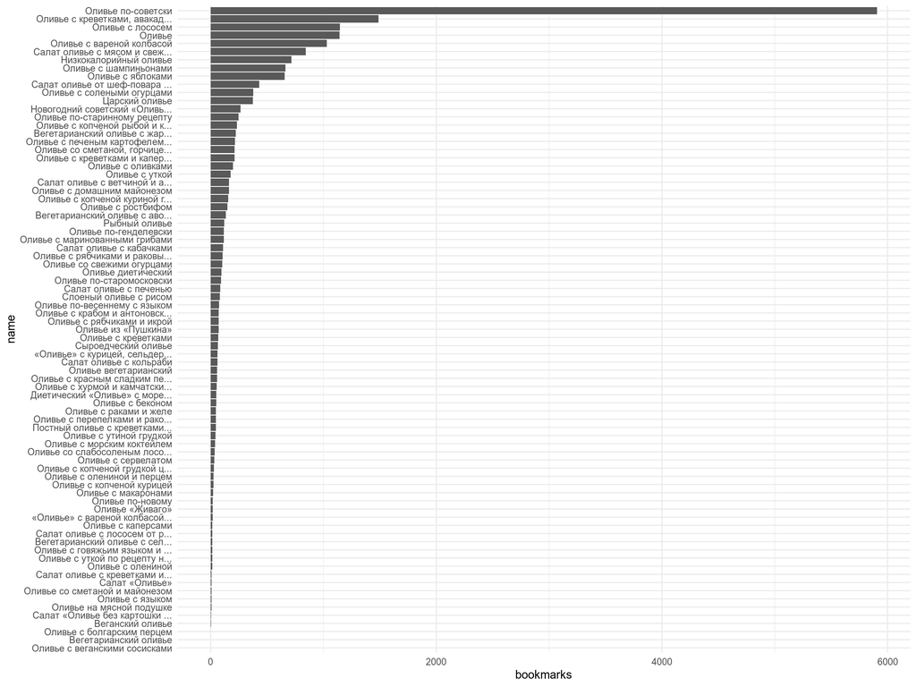

```r
eda_recipies %>%
  mutate(name = str_trunc(name, 30),
         name = reorder(name, bookmarks)) %>%
  ggplot(aes(name, bookmarks))+
  geom_col()+
  coord_flip()
```

So we can use a `links` variable to parse all ingredients from each page:

```r
eda_recipies$ingredients  <- lapply(eda_recipies$link, function(link){
source <- xml2::read_html(link)
source %>%
  rvest::html_node("div.ingredients-list") %>%
  rvest::html_text()
})

eda_recipies$ingredients <- unlist(eda_recipies$ingredients)
```

Lets have a look on the result:

```r
head(eda_recipies$ingredients, 2)
```

```
## [1] "\n  \n  Ингредиенты\n  \n    порции\n    \n      \n    \n      \n  \n\n\n  \n    \n      \n        Картофель\n      \n    \n    7 штук\n  \n  \n    \n      \n        Морковь\n      \n    \n    5 штук\n  \n  \n    \n      \n        Маринованные огурцы\n      \n    \n    6 штук\n  \n  \n    \n…
## [2] "\n  \n  Ингредиенты\n  \n    порции\n    \n      \n    \n      \n  \n\n\n  \n    \n      \n        Очищенные вареные креветки\n      \n    \n    200 г\n  \n  \n    \n      \n        Авокадо\n      \n    \n    2 штуки\n  \n  \n    \n      \n        Морковь\n      \n    \n    2 штуки\n  \n  \n…
```

```r
eda_recipies %>%
  mutate(ingredients = str_replace_all(ingredients, "(\n\\s*){5}", "_"),
         ingredients = str_replace_all(ingredients, "(\n\\s*){3}", "@"),
         ingredients = str_remove(ingredients, "_\\s*window.*\n"),
         ingredients = str_remove(ingredients, "\\s*Ингредиенты\\s*порции_")) %>%
  tidytext::unnest_tokens(ingredient, ingredients, token = str_split, pattern = "_") %>%
  separate(ingredient, into = c("ingredient", "measure"), sep = "@") %>%
  mutate(amount = as.numeric(str_extract(measure, "\\d{1,}\\.?\\d{0,}")),
         measure = str_remove_all(measure, "[\\d\\.]"),
         amount = ifelse(str_detect(measure, "½"), "0.5", amount),
         amount = ifelse(str_detect(measure, "¼"), "0.25", amount),
         measure = str_remove_all(measure, "½ |¼ ")) ->
  eda_recipies
```

I created new columns `ingredient`, `amount`, `measure`:

```r
eda_recipies %>%
  select(ingredient, amount, measure)
```

| ingredient | amount | measure |
| --- | --- | --- |
| картофель | 7 | штук |
| морковь | 5 | штук |
| маринованные огурцы | 6 | штук |
| консервированный зеленый горошек | 1 | банка |
| яйцо куриное | 6 | штук |
| докторская колбаса | 300 | г |
| сметана | 100 | г |
| майонез | 200 | г |
| соль | NA | по вкусу |
| очищенные вареные креветки | 200 | г |

[output cut: 924 more lines]

## 3. Analyse data from https://eda.ru

I obtained data from 79 recipies. I already can list all unique 227 ingridients and use it in the second survey. But lets try to visualise first. What is the most frequent ingredient in Russian Olivier salad?

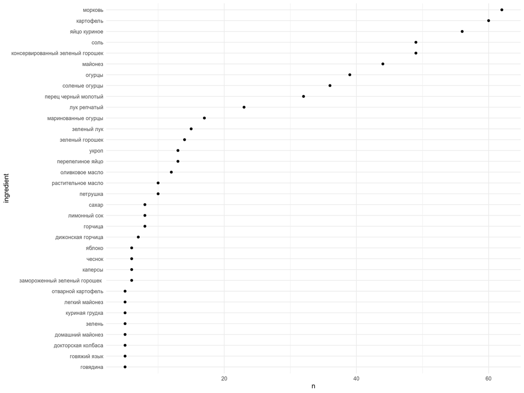

```r
eda_recipies %>%
  count(ingredient, sort = TRUE) %>%
  mutate(ingredient = reorder(ingredient, n)) %>%
  filter(n > 4) %>%
  ggplot(aes(ingredient, n))+
  geom_point()+
  coord_flip()
```

On this graph we can see our first problem: there are multiple entries in a dataset of

- **peas**: *консервированный зеленый горошек*, *зеленый горошек*, *замороженный зеленый горошек*, *вареный зеленый горошек*, *горох*);
- **potatoes**: *картофель*, *отварной картофель*, *мини картофель*, *молодой картофель*;
- **mayonnaise**: *майонез*, *легкий майонез*, *майонез «Провансаль»*;
- **pepper**: *сладкий перец*, *красный сладкий перец*
- **pepper** (spice): *перец черный молотый*, *черный перец горошком*, *душистый перец горошком*, *молотый белый перец*, *свежемолотый черный перец*
- **onion**: *лук репчатый*, *красный лук*, *лук*, *белый лук*, *зеленый лук с луковицей*, *лук-шалот*
- **dill**: *измельченный укроп*, *укроп*
- **olive oil**: *оливковое масло*, *оливковое масло extra virgin*, *растительное масло*
- **lemon**: *лимон*, *лимонный сок*
- **parsley**: *петрушка*, *рубленая петрушка*
- **mustard**: *горчица*, *столовая горчица*
- **beef**: *говядина*, *вареная говядина*
- **capers**: *каперсы*, *маринованные каперсы*

So I decided normalise this part keeping different types of products (e. g. *красный лук* ‘red onion’, and *белый лук* ‘white onion’ stay different):

```r
eda_recipies %>%
  mutate(ingredient = str_replace_all(ingredient, "консервированный зеленый горошек|горох|замороженный зеленый горошек|вареный зеленый горошек", "зеленый горошек"),
         ingredient = str_replace_all(ingredient, "отварной картофель|мини картофель|молодой картофель", "картофель"),
         ingredient = str_replace_all(ingredient, "красный сладкий перец", "сладкий перец"),
         ingredient = str_replace_all(ingredient, "легкий майонез|майонез «Провансаль»", "майонез"),
         ingredient = str_replace_all(ingredient, "перец черный молотый|душистый перец горошком|свежемолотый черный перец", "черный перец"),
         ingredient = str_replace_all(ingredient, "лук репчатый|лук|зеленый лук с луковицей", "репчатый лук"),
         ingredient = str_replace_all(ingredient, "оливковое масло extra virgin", "оливковое масло"),
         ingredient = str_replace_all(ingredient, "рубленая петрушка", "петрушка"),
         ingredient = str_replace_all(ingredient, "столовая горчица", "горчица"),
         ingredient = str_replace_all(ingredient, "вареная говядина", "говядина"),
         ingredient = str_replace_all(ingredient, "маринованные каперсы", "каперсы"),
         ingredient = str_remove(ingredient, "^ "),
         measure = str_remove(measure, "^ ")) ->
  eda_recipies
```

Now the number of unique ingredients is 211. They still need manual categorization. Since ingridient frequncies have changed, I redraw the frequency graph:

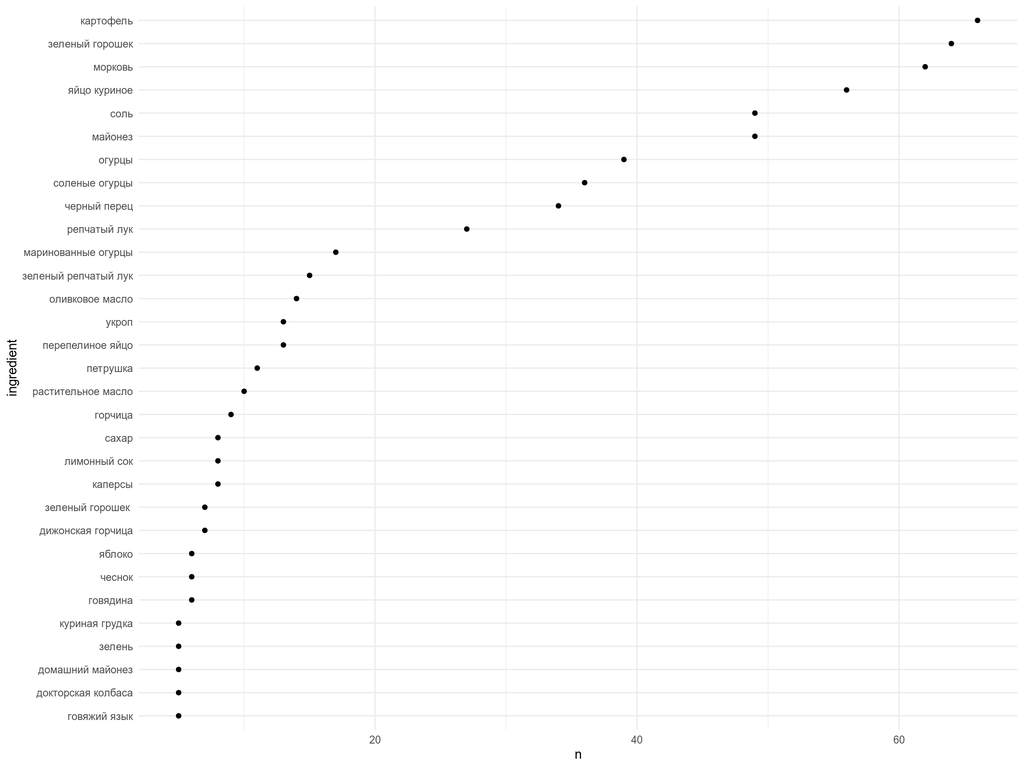

```r
eda_recipies %>%
  count(ingredient, sort = TRUE) %>%
  mutate(ingredient = reorder(ingredient, n)) %>%
  filter(n > 4) %>%
  ggplot(aes(ingredient, n))+
  geom_point()+
  coord_flip()
```

And here we see that the majority of Russian Olivier salads should contain green peas, potates and carrot!

Is it possible to work with the variable `amount`? All recipies are created for different number of portions, but this information is encoded in a variable `portions`. I can devide one column by another, but there still will be a problem of different measures, e. g. dill have several measures in our dataset: *г* ‘gram’, *пучок* ‘bundle’, *ветка* ‘twig’ and … *по вкусу* ‘as you wish’. I can sort ingredients by number of measures:

```r
eda_recipies %>%
  group_by(ingredient) %>%
  summarise(measure_unique = length(unique(measure))) %>%
  arrange(desc(measure_unique))
```

| ingredient | measure_unique |
| --- | --- |
| горчица | 6 |
| дижонская горчица | 5 |
| зеленый горошек | 5 |
| оливковое масло | 5 |
| сахар | 5 |
| каперсы | 4 |
| картофель | 4 |
| майонез | 4 |
| маринованные огурцы | 4 |
| морковь | 4 |

[output cut: 201 more lines]

Partially it could be explained by the case of the measures (since it is not always nominative), but some times something could be measured in grams and in spoons. We will ignore this problem and continue as if everything within one ingredient is comparable. It is possible to run PCA on this data, so I ran and didn’t get anything usefull from it. So for the next survey we need to threw out some rare ingredients and add created a fixed list in question form.

```r
eda_recipies %>%
  mutate(amount = ifelse(is.na(amount), 0.05, amount),
         amount = as.numeric(amount)/portions) %>%
  write_csv("data/eda_recipies_final.csv")
```

## 4. Analyse results of the second survey

After the first survey I’ve created a [Google form](https://forms.gle/D55S8Jxh6VszALmL9).